# Autoencoders para Detecção de Fraudes

## 1. Importar Bibliotecas

```python
import pandas as pd
import numpy as np
import matplotlib.pyplot as plt
import seaborn as sns

from sklearn.preprocessing import StandardScaler
from sklearn.model_selection import train_test_split
from sklearn.utils import shuffle
from sklearn.metrics import classification_report, confusion_matrix, precision_recall_curve

from tensorflow.keras.models import Model, load_model
from tensorflow.keras.layers import Input, Dense
from tensorflow.keras import regularizers
from tensorflow.keras.callbacks import ModelCheckpoint, TensorBoard
```

## 2. Carregar dados

```python
dataset.describe()
```

|  | Time | V1 | V2 | V3 | V4 | V5 | V6 | V7 | V8 | V9 | ... | V21 | V22 | V23 | V24 | V25 | V26 | V27 | V28 | Amount | Class |
| --- | --- | --- | --- | --- | --- | --- | --- | --- | --- | --- | --- | --- | --- | --- | --- | --- | --- | --- | --- | --- | --- |
| count | 284807.000000 | 2.848070e+05 | 2.848070e+05 | 2.848070e+05 | 2.848070e+05 | 2.848070e+05 | 2.848070e+05 | 2.848070e+05 | 2.848070e+05 | 2.848070e+05 | ... | 2.848070e+05 | 2.848070e+05 | 2.848070e+05 | 2.848070e+05 | 2.848070e+05 | 2.848070e+05 | 2.848070e+05 | 2.848070e+05 | 284807.000000 | 284807.000000 |
| mean | 94813.859575 | 1.165980e-15 | 3.416908e-16 | -1.373150e-15 | 2.086869e-15 | 9.604066e-16 | 1.490107e-15 | -5.556467e-16 | 1.177556e-16 | -2.406455e-15 | ... | 1.656562e-16 | -3.444850e-16 | 2.578648e-16 | 4.471968e-15 | 5.340915e-16 | 1.687098e-15 | -3.666453e-16 | -1.220404e-16 | 88.349619 | 0.001727 |
| std | 47488.145955 | 1.958696e+00 | 1.651309e+00 | 1.516255e+00 | 1.415869e+00 | 1.380247e+00 | 1.332271e+00 | 1.237094e+00 | 1.194353e+00 | 1.098632e+00 | ... | 7.345240e-01 | 7.257016e-01 | 6.244603e-01 | 6.056471e-01 | 5.212781e-01 | 4.822270e-01 | 4.036325e-01 | 3.300833e-01 | 250.120109 | 0.041527 |
| min | 0.000000 | -5.640751e+01 | -7.271573e+01 | -4.832559e+01 | -5.683171e+00 | -1.137433e+02 | -2.616051e+01 | -4.355724e+01 | -7.321672e+01 | -1.343407e+01 | ... | -3.483038e+01 | -1.093314e+01 | -4.480774e+01 | -2.836627e+00 | -1.029540e+01 | -2.604551e+00 | -2.256568e+01 | -1.543008e+01 | 0.000000 | 0.000000 |
| 25% | 54201.500000 | -9.203734e-01 | -5.985499e-01 | -8.903648e-01 | -8.486401e-01 | -6.915971e-01 | -7.682956e-01 | -5.540759e-01 | -2.086297e-01 | -6.430976e-01 | ... | -2.283949e-01 | -5.423504e-01 | -1.618463e-01 | -3.545861e-01 | -3.171451e-01 | -3.269839e-01 | -7.083953e-02 | -5.295979e-02 | 5.600000 | 0.000000 |
| 50% | 84692.000000 | 1.810880e-02 | 6.548556e-02 | 1.798463e-01 | -1.984653e-02 | -5.433583e-02 | -2.741871e-01 | 4.010308e-02 | 2.235804e-02 | -5.142873e-02 | ... | -2.945017e-02 | 6.781943e-03 | -1.119293e-02 | 4.097606e-02 | 1.659350e-02 | -5.213911e-02 | 1.342146e-03 | 1.124383e-02 | 22.000000 | 0.000000 |
| 75% | 139320.500000 | 1.315642e+00 | 8.037239e-01 | 1.027196e+00 | 7.433413e-01 | 6.119264e-01 | 3.985649e-01 | 5.704361e-01 | 3.273459e-01 | 5.971390e-01 | ... | 1.863772e-01 | 5.285536e-01 | 1.476421e-01 | 4.395266e-01 | 3.507156e-01 | 2.409522e-01 | 9.104512e-02 | 7.827995e-02 | 77.165000 | 0.000000 |
| max | 172792.000000 | 2.454930e+00 | 2.205773e+01 | 9.382558e+00 | 1.687534e+01 | 3.480167e+01 | 7.330163e+01 | 1.205895e+02 | 2.000721e+01 | 1.559499e+01 | ... | 2.720284e+01 | 1.050309e+01 | 2.252841e+01 | 4.584549e+00 | 7.519589e+00 | 3.517346e+00 | 3.161220e+01 | 3.384781e+01 | 25691.160000 | 1.000000 |

8 rows × 31 columns

## 3. Análise Exploratória

### 3.1. Distribuição dos Dados com base na Classe

```python
print("Distribuição das classificações dos dados:")
print(f"Transações Não Fraudulentas: {round(dataset['Class'].value_counts()[0]/len(dataset) * 100,2)}%.")
print(f"Transações Fraudulentas: {round(dataset['Class'].value_counts()[1]/len(dataset) * 100,2)}%.")
```

```
Distribuição das classificações dos dados:
Transações Não Fraudulentas: 99.83%.
Transações Fraudulentas: 0.17%.
```

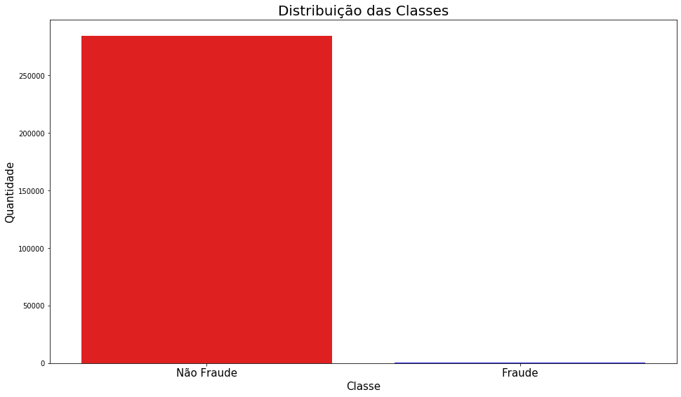

```python
plot_distribuicao()
```

### 3.2. Existe diferência nos valores das transações fraudulentas e não fraudulentas?

```python
print(f"Transações Não Fraudulentas:\n{n_fraude.describe()}")
print()
print(f"Transações Fraudulentas:\n{fraude.describe()}")
```

```
Transações Não Fraudulentas:
count    284315.000000
mean         88.291022
std         250.105092
min           0.000000
25%           5.650000
50%          22.000000
75%          77.050000
max       25691.160000
Name: Amount, dtype: float64

Transações Fraudulentas:
count     492.000000
mean      122.211321
std       256.683288
min         0.000000
25%         1.000000
50%         9.250000
75%       105.890000
max      2125.870000
Name: Amount, dtype: float64
```

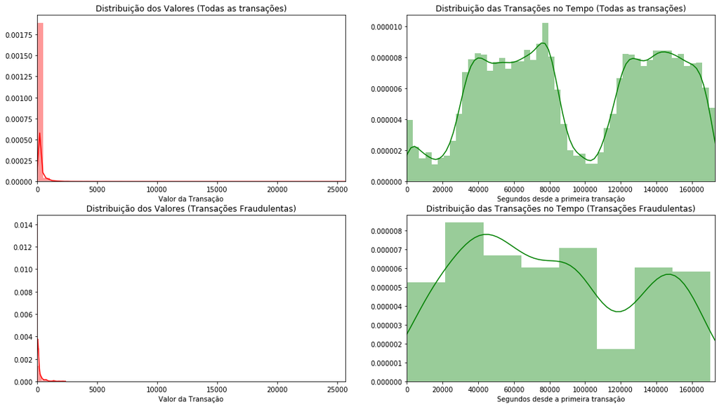

```python
plot_comparacoes()
```

## 4. Processamento dos dados

### 4.1. Aplicar técnica de padronização na feature 'Amount'.

- Aplicamos a técnica pois a feature apresenta uma gama grande de valores.

```python
# Remoção da coluna relacionada ao tempo
df = dataset.drop(['Time'], axis=1)

# Normalização da coluna relacionada ao valor da transação
sc = StandardScaler()
df['Amount'] = sc.fit_transform(df['Amount'].values.reshape(-1, 1))
```

### 4.2. Separar os dados normais dos dados fraudulentos.

```python
# Separação das classes de dados
fraud_data = df[df['Class'] == 1]
n_fraud_data = df[df['Class'] == 0]
```

### 4.3. Separar dados de Treino e Teste.

```python
# Separação dos dados de treino e de teste
X_train, X_test = train_test_split(n_fraud_data, test_size = 0.2)

X_train = X_train.drop(columns = ['Class']).copy()

X_test_full = pd.concat([X_test, fraud_data], ignore_index=True, sort=False)
X_test_full = shuffle(X_test_full)

y_test = X_test_full['Class'].copy()
X_test = X_test_full.drop(columns = ['Class'])

print('Dimensionalidade dos dados:')
print(f'Treinamento: {X_train.shape}')
print(f'Teste (Fraudulentos): {fraud_data.shape}, Teste (Não Fraudulentos): {X_test.shape}')
```

```
Dimensionalidade dos dados:
Treinamento: (227452, 29)
Teste (Fraudulentos): (492, 30), Teste (Não Fraudulentos): (57355, 29)
```

## 5. Autoencoder

### 5.1. Introdução

Dessa forma, o Autoencoder codifica as informações mais relevantes dos dados não fraudulentos. Intuitivamente, podemos dizer que dessa maneira o algoritimo aprende apenas o que é uma transação de cartão de crédito absolutamente normal.

E esse conceito aprendido de uma transação normal com cartão de crédito pode ser encontrado como a representação latente na camada intermediária, usada para recriar os recursos originais usados como dados de entrada para o Autoencoder.

Após o treinamento com os dados não fraudulentos, podemos finalmente usar o Auto Encoder para detectar as anomalias (fraudes).

Com isso, é possível mostrar para o Auto Encoder os dados de ambos os tipos - anomalias e dados normais. Como antes, os recursos de entrada são codificados pelo Autoencoder em uma representação latente que é usada para reconstruir a entrada. Os dados de fraude vão possuir um erro de reconstruçãão muito superior aos dados normais, pois o Auto Encoder aprendeu a codificar dados de transações normais.

### 5.2. Construção do Auto Encoder utilizando o framework Keras

```python
# Dimensões dos dados de entrada
input_dim = X_train.shape[1]

input_layer = Input(shape=(input_dim, ))

# Camadas de encoding
encoder = Dense(18, activation="relu")(input_layer)
encoder = Dense(14, activation="relu", activity_regularizer=regularizers.l2(10e-5))(encoder)
encoder = Dense(10, activation="relu")(encoder)

# Camadas de decoding
decoder = Dense(14, activation='relu')(encoder)
decoder = Dense(18, activation='relu')(decoder)
decoder = Dense(input_dim, activation='relu')(decoder)

autoencoder = Model(inputs=input_layer, outputs=decoder)

autoencoder.compile(optimizer='adam', loss='mean_squared_error', metrics=['accuracy'])

checkpointer = ModelCheckpoint(filepath="./model/model.h5", verbose=0, save_best_only=True)

tensorboard = TensorBoard(log_dir='./logs', histogram_freq=0, write_graph=True, write_images=True)
```

### 5.3. Sumário da Rede Neural

```python
autoencoder.summary()
```

```
Model: "model"
_________________________________________________________________
Layer (type)                 Output Shape              Param #
=================================================================
input_1 (InputLayer)         [(None, 29)]              0
_________________________________________________________________
dense (Dense)                (None, 18)                540
_________________________________________________________________
dense_1 (Dense)              (None, 14)                266
_________________________________________________________________
dense_2 (Dense)              (None, 10)                150
_________________________________________________________________
dense_3 (Dense)              (None, 14)                154
_________________________________________________________________
dense_4 (Dense)              (None, 18)                270
_________________________________________________________________
dense_5 (Dense)              (None, 29)                551
=================================================================
Total params: 1,931
Trainable params: 1,931
Non-trainable params: 0
_________________________________________________________________
```

### 5.4. Treinamento do Auto Encoder

```python
# Treinamento da rede utilizando 15 Épocas e um tamanho de batch de 2048

EPOCHS = 15
BS = 2048

history = autoencoder.fit(X_train, X_train,
                          epochs = EPOCHS,
                          batch_size = BS,
                          shuffle=True,
                          validation_data=(X_test, X_test),
                          verbose=1).history
```

### 5.5. Gráfico de Erro de Validação do Modelo

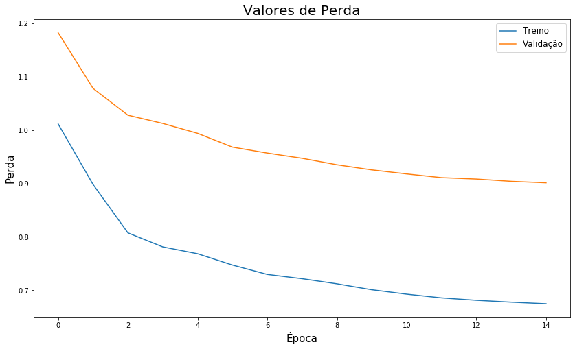

```python
plot_loss_chart()
```

## 6. Predição

### 6.1. Demonstração dos erros de reconstrução nos dados de Teste

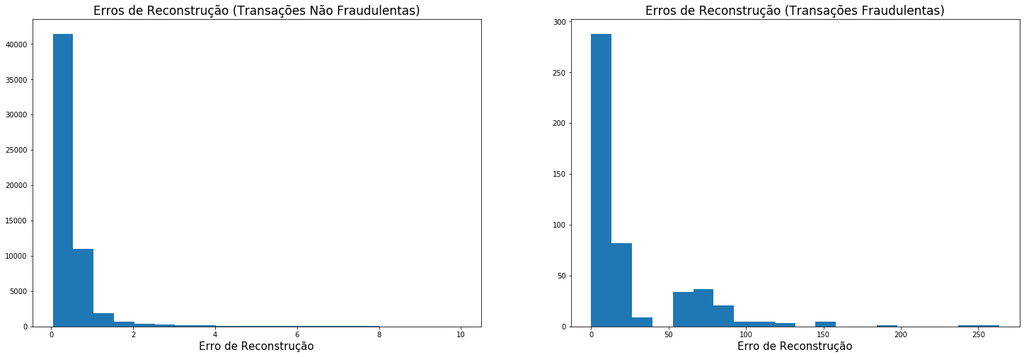

```python
plot_reconstruction_error()
```

## 7. Métricas

### 7.1 Precisão vs Revocação (Recall)

[figure not shown]

Precisão e Recall são definidos das seguintes maneiras:

$$\text{Precisão} = \frac{\text{verdadeiros positivos}}{\text{verdadeiros positivos} + \text{falsos positivos}}$$$$\text{Revocação} = \frac{\text{verdadeiros positivos}}{\text{verdadeiros positivos} + \text{falsos negativos}}$$

**Precisão** (também chamada de valor preditivo positivo) é a fração de instâncias recuperadas que são relevantes.

**Revocação** (também conhecida como sensibilidade) é a fração de instâncias relevantes que são recuperadas.

Tanto precisão quanto revocação são, portanto, bases para o estudo e compreensão da medida de relevância.

Alto recall, mas baixa precisão significa muitos resultados, a maioria dos quais tem pouca ou nenhuma relevância. Quando a precisão é alta, mas o recall é baixo, temos o oposto - poucos resultados retornados com uma relevância muito alta. Normalmente, o resultado ideal seria ter uma alta precisão e alto recall.

### 7.2 F1 Score

F1 Score é uma medida que combina precisão e revocação é a média harmónica entre precisão e revocação

$${\displaystyle F1=2\cdot {\frac {\mathrm {precisão} \cdot \mathrm {revocação} }{\mathrm {precisão} +\mathrm {revocação} }}}$$

Esta medida é aproximadamente a média de ambas quando seus valores estão próximos, e de maneira mais geral, o quadrado da média geométrica dividido pela média aritmética. Há várias razões pelas quais o F1 Score pode ser criticado em casos específicos devido ao seu viés como métrica de avaliação.

### 7.3 Comparação das métricas para o modelo gerado

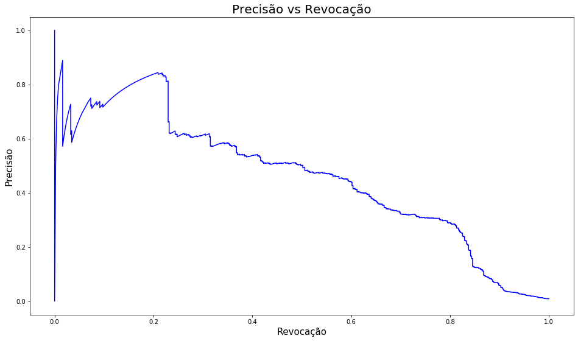

```python
plot_prec_rev()
```

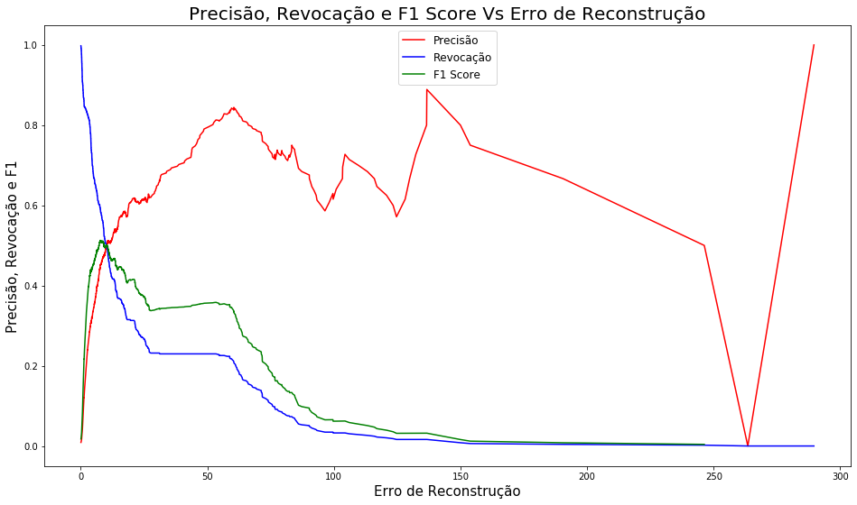

```python
plot_metrics()
```

#### 7.3.1 Valor balanceado entre Precisão e Revocação

- Utilizando um limite que otimiza o valor da métrica F1-Score, balanceado entre precisão e Revocação.

```python
print('Valor máximo de F1 Score: ', str(max(F1_score)))
```

```
Valor máximo de F1 Score:  0.5127304653204565
```

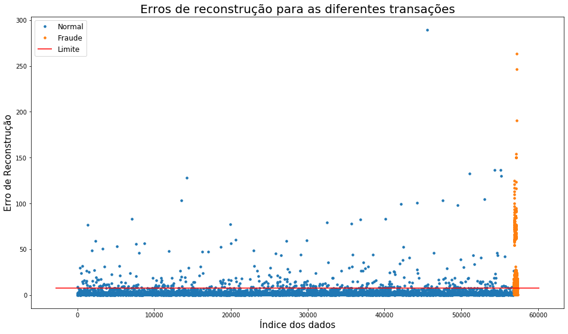

```python
plot_reconstruction_error(error_df, threshold_max_f1)
```

#### 7.3.2 Matriz de Confusão

- O limite utilizado foi o valor que representa o maior resultado para a métrica de F1-Score.

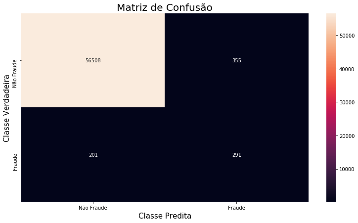

```python
y_pred = plot_confusion_matrix(error_df, threshold_max_f1, (13, 7))
```

```python
print(classification_report(error_df.true_class, y_pred))
```

```
              precision    recall  f1-score   support

           0       1.00      0.99      1.00     56863
           1       0.45      0.59      0.51       492

    accuracy                           0.99     57355
   macro avg       0.72      0.79      0.75     57355
weighted avg       0.99      0.99      0.99     57355
```

#### AJUSTE FINO: Otimizando valor de Threshold para melhor resultado de Revocação

- O objetivo é minimizar o falso negativo, o caso de ser uma transação fraudulenta e o algoritmo predizer que é uma transação normal. O limite utilizado foi de 3,2.

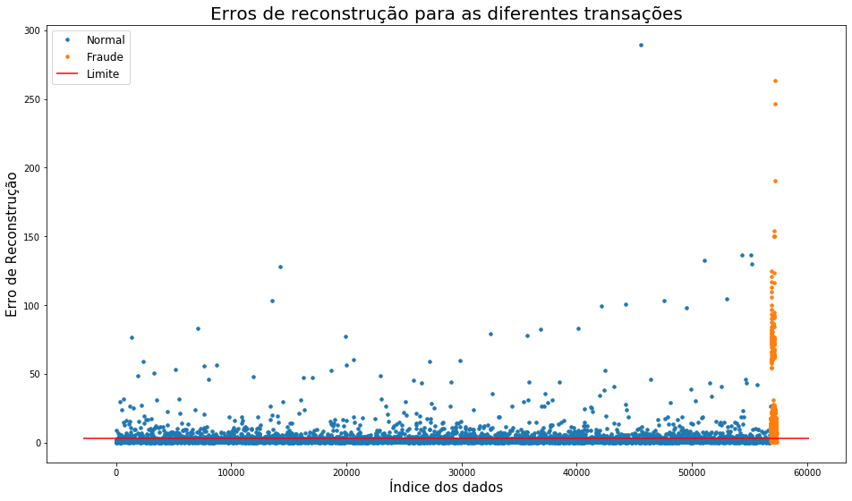

```python
plot_reconstruction_error(error_df, threshold)
```

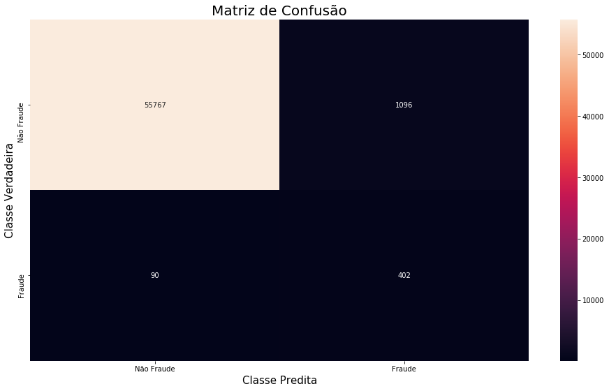

```python
y_pred = plot_confusion_matrix(error_df, threshold)
```

```python
print(classification_report(error_df.true_class, y_pred))
```

```
              precision    recall  f1-score   support

           0       1.00      0.98      0.99     56863
           1       0.27      0.82      0.40       492

    accuracy                           0.98     57355
   macro avg       0.63      0.90      0.70     57355
weighted avg       0.99      0.98      0.98     57355
```